# STT465_Report_No_Code

```r
HPDinterval <- function(obj, prob = 0.95, ...) UseMethod("HPDinterval")

HPDinterval.mcmc <- function(obj, prob = 0.95, ...)
{
    obj <- as.matrix(obj)
    vals <- apply(obj, 2, sort)
    if (!is.matrix(vals)) stop("obj must have nsamp > 1")
    nsamp <- nrow(vals)
    npar <- ncol(vals)
    gap <- max(1, min(nsamp - 1, round(nsamp * prob)))
    init <- 1:(nsamp - gap)
    inds <- apply(vals[init + gap, ,drop=FALSE] - vals[init, ,drop=FALSE],
                  2, which.min)
    ans <- cbind(vals[cbind(inds, 1:npar)],
                 vals[cbind(inds + gap, 1:npar)])
    dimnames(ans) <- list(colnames(obj), c("lower", "upper"))
    attr(ans, "Probability") <- gap/nsamp
    ans
}

HPDinterval.mcmc.list <- function(obj, prob = 0.95, ...)
    lapply(obj, HPDinterval, prob)
# source: https://github.com/cran/coda/blob/master/R/HPDinterval.R
```

```r
print("The below shows the posterior mean and standard deviation")
```

```
## [1] "The below shows the posterior mean and standard deviation"
```

```r
summary(B)
```

```
##
## Iterations = 1:14500
## Thinning interval = 1
## Number of chains = 1
## Sample size per chain = 14500
##
## 1. Empirical mean and standard deviation for each variable,
##    plus standard error of the mean:
##
##                   Mean        SD  Naive SE Time-series SE
## (Intercept)  8.683e-05 5.286e-04 4.390e-06      1.441e-05
## equipOS-CC  -4.440e-05 5.286e-04 4.390e-06      8.915e-06
## equipOS-PC   5.815e-05 7.280e-04 6.046e-06      1.246e-05
## equipPAPER   3.699e-06 1.858e-03 1.543e-05      1.651e-05
## equipPUNCH  -7.926e-05 7.731e-04 6.421e-06      9.907e-06
## econpoor     8.088e-05 5.149e-04 4.276e-06      9.954e-06
## econrich    -1.819e-04 8.315e-04 6.905e-06      1.621e-05
## gore        -6.646e-07 4.990e-07 4.144e-09      3.281e-07
## bush        -6.266e-07 4.727e-07 3.925e-09      3.115e-07
## ballots      6.126e-07 4.603e-07 3.823e-09      3.356e-07
## undercount   9.963e-01 1.046e-02 8.688e-05      2.972e-04
##
## 2. Quantiles for each variable:
##
##                   2.5%        25%        50%        75%     97.5%
## (Intercept) -9.463e-04 -2.694e-04  9.237e-05  4.401e-04 1.127e-03
## equipOS-CC  -1.090e-03 -3.929e-04 -4.572e-05  3.074e-04 9.995e-04
## equipOS-PC  -1.351e-03 -4.348e-04  5.436e-05  5.434e-04 1.506e-03
## equipPAPER  -3.691e-03 -1.240e-03  2.040e-05  1.259e-03 3.588e-03
## equipPUNCH  -1.589e-03 -6.031e-04 -8.250e-05  4.426e-04 1.429e-03
## econpoor    -9.309e-04 -2.597e-04  8.227e-05  4.250e-04 1.085e-03
## econrich    -1.802e-03 -7.433e-04 -1.786e-04  3.691e-04 1.453e-03
## gore        -1.636e-06 -1.042e-06 -6.074e-07 -2.696e-07 1.301e-07
## bush        -1.566e-06 -9.930e-07 -5.740e-07 -2.529e-07 1.271e-07
## ballots     -1.175e-07  2.500e-07  5.614e-07  9.681e-07 1.518e-06
## undercount   9.753e-01  9.894e-01  9.964e-01  1.003e+00 1.016e+00
```

```r
summary(varE)
```

```
##
## Iterations = 1:14500
## Thinning interval = 1
## Number of chains = 1
## Sample size per chain = 14500
##
## 1. Empirical mean and standard deviation for each variable,
##    plus standard error of the mean:
##
##           Mean             SD       Naive SE Time-series SE
##      6.707e-06      7.924e-07      6.581e-09      7.246e-09
##
## 2. Quantiles for each variable:
##
##      2.5%       25%       50%       75%     97.5%
## 5.355e-06 6.147e-06 6.641e-06 7.195e-06 8.474e-06
```

```r
##### Gibbs Sampler for Normal Model #############

#Outputs the plot of Posterior

mu=mean(gavote$undercount)
y=gavote$undercount


## Hyper-parameters (i.e., parameters of the prior distribution(s))
mu_0 =1
sigma_0 =1

a =1
b = 1
lambd_init = 1

## Gibbs Sampler

# Initialization

ybar=mean(y)
# input <- list(y,mu_0,sigma_0, a, b, lambd_init)
# Sampling function

gibbs_N <- function(input, S, seed){
  set.seed(seed)
  ybar <- mean(input$y)
  n <- length(input$y)
  para1 <- matrix(NA,S, 2)
  lambd <- input$lambd_init

for(i in 1:S){
  mu1 = (input$mu_0/input$sigma_0^2+n*lambd*ybar)/(1/input$sigma_0^2+n*lambd)
  sigma1 =sqrt(1/(1/input$sigma_0^2)+n*lambd)
  mu <-rnorm(1,mean=mu1,sd=sigma1)
  a1 <-input$a +n/2
  b1 <- input$b +sum(input$y - mu)^2/2
  lambd <- rgamma(1, shape = a1, rate = b1)
  para1[i,] <- c(mu,lambd)
}
  print(para1)
}

input <- list(y=y,mu_0=5,sigma_0 = 1, a = 1, b =1, lambd_init =1)
output<- gibbs_N(input, S=1000, seed = 10212019)
```

[output not shown]

[output cut: 986 more lines]

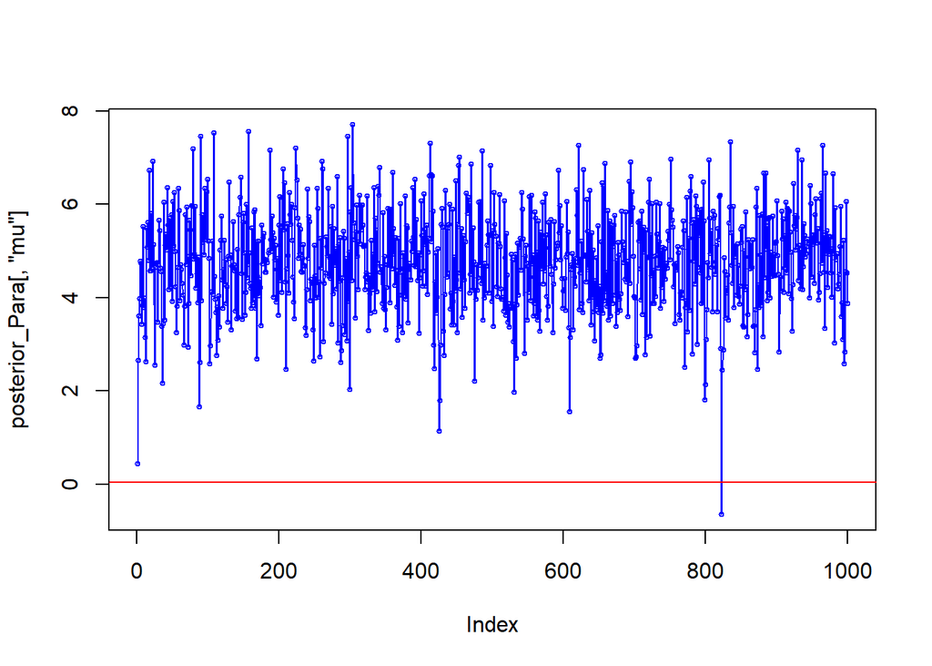

```r
posterior_Para <- as.data.frame(output)
names(posterior_Para) <- c("mu", "lambda=1/sigma^2")


plot(posterior_Para[,"mu"],type='o',cex=.5,col=4)  # Traceplot
abline(h=mean(y),col=2)
```

We can now visualize the posterior distribution and create an HPD interval for all the variables in the model.

```r
print("The below shows the posterior credibility interval")
```

```
## [1] "The below shows the posterior credibility interval"
```

```r
HPDinterval(B,prob=.95)
```

```
##                     lower        upper
## (Intercept) -9.298935e-04 1.138640e-03
## equipOS-CC  -1.078090e-03 1.008721e-03
## equipOS-PC  -1.354587e-03 1.499532e-03
## equipPAPER  -3.568837e-03 3.662519e-03
## equipPUNCH  -1.593532e-03 1.422974e-03
## econpoor    -9.319083e-04 1.081213e-03
## econrich    -1.769492e-03 1.480296e-03
## gore        -1.637082e-06 1.291341e-07
## bush        -1.553927e-06 1.338634e-07
## ballots     -1.250755e-07 1.506955e-06
## undercount   9.763523e-01 1.017241e+00
## attr(,"Probability")
## [1] 0.95
```

We can also see the distribution of our samples at the variable level:

```r
######## Gibbs Analysis #######

x = as.ts(gavote1)
SAMPLES<-as.mcmc(x) # converting your samples into an MCMC object
# Set lag of 20
autocorr(SAMPLES, lags = c(20), relative=TRUE)
```

```
## , , equip
##
##             equip      econ        gore      bush     ballots  undercount
## Lag 20 -0.1370968 0.0486471 -0.08550143 -0.054223 -0.07376014 -0.05477138
##
## , , econ
##
##              equip        econ       gore       bush    ballots  undercount
## Lag 20 -0.01832662 -0.01086361 0.04779106 0.06728126 0.06143212 -0.09168336
##
## , , gore
##
##             equip      econ        gore        bush     ballots  undercount
## Lag 20 -0.1003029 0.0346935 -0.02326343 -0.02531419 -0.02594341 -0.03720016
##
## , , bush
##
##              equip       econ        gore        bush     ballots undercount
## Lag 20 -0.09561629 0.09084396 -0.02711586 -0.01091682 -0.02068502 -0.1649025
##
## , , ballots
##
##             equip       econ        gore        bush     ballots undercount
## Lag 20 -0.1037921 0.06743382 -0.02630033 -0.01838111 -0.02405078  -0.107293
##
## , , undercount
##
##              equip        econ      gore      bush   ballots undercount
## Lag 20 -0.01565368 -0.05810611 0.1189557 0.1163424 0.1259678  0.0126133
```

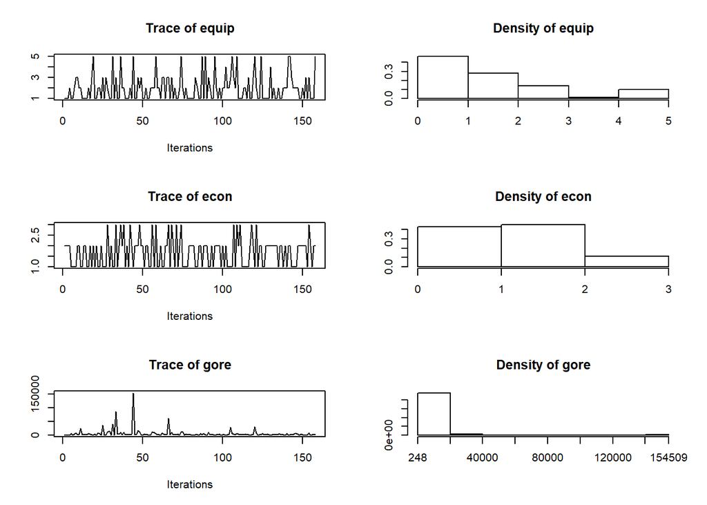

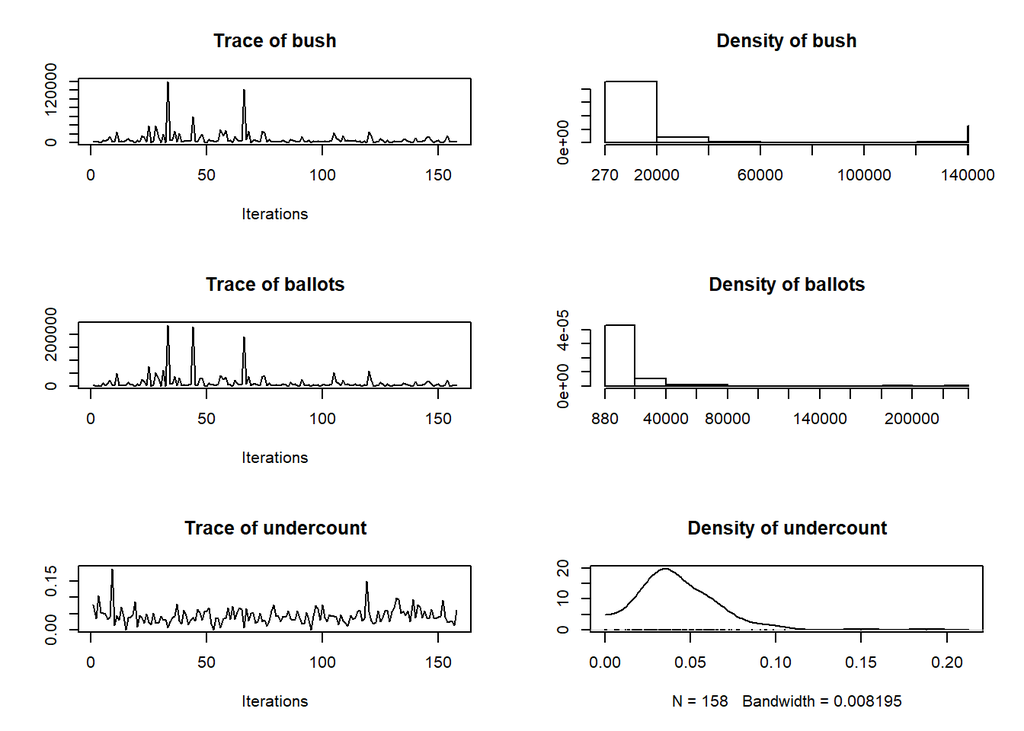

```r
plot(SAMPLES) # this produces both density and trace plot
```

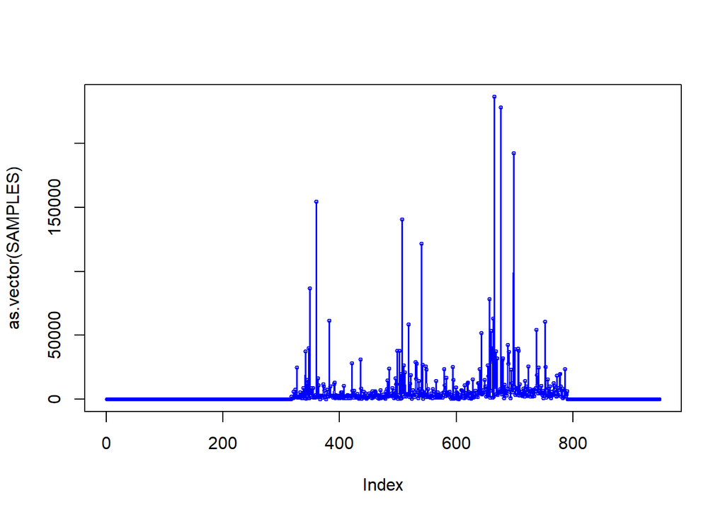

```r
plot(as.vector(SAMPLES),type='o',cex=.5,col=4)
```

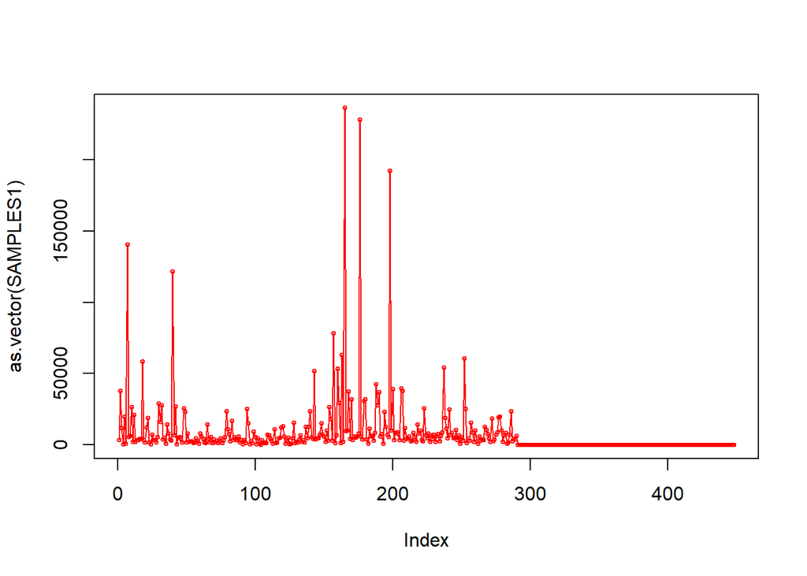

```r
burnIn=1:500
SAMPLES1=SAMPLES[-burnIn] # removing burn-in
plot(as.vector(SAMPLES1),type='o',cex=.5,col=2)
```

```r
summary(SAMPLES1)
```

```
##      Min.   1st Qu.    Median      Mean   3rd Qu.      Max.
##      0.00      0.05   2566.00   7925.52   6825.25 236525.00
```

```r
effectiveSize(SAMPLES1)
```

```
##     var1
## 31.75344
```

Now we can draw from our prior and perform hypothesis testing. This is not effective as with our prior we have nothing to test against. We can, however, see the density of our posterior * sample of the prior.

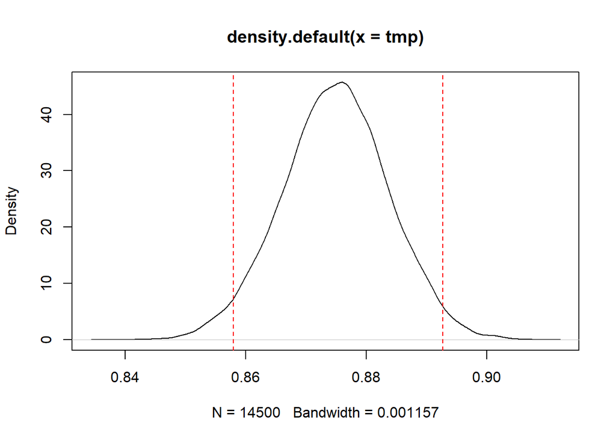

```r
######## Bayesian Linear Hypothesis  #######

# Drawing from our flat prior [0:1]
contrast=runif(n=11, min=1e-12, max=.9999999999)
tmp=B%*%contrast
plot(density(tmp));abline(v=0)
abline(v=HPDinterval(as.mcmc(tmp),p=.95),col=2,lty=2)
```

```r
mean(tmp>0)
```

```
## [1] 1
```

```r
mean(tmp<0)
```

```
## [1] 0
```

## Final Models and Statistical Analysis

Overall, we have two final models:

## OLS Frequentist Regression

$$\text{Final Model (OLS Frequentist Regression): }$$
$$\text{UNDERCOUNT} = 5.807496*10^{-3}x_1 + 2.273752*10^{-2}x_2 - 9.044148*10^{-3}x_3 + 6.082960*10^{-3}x_4 + 2.089696 * 10^{-2}x_5 -1.894076*10^{-2}x_6 \\ - 3.554025*10^{-5}x_7 -3.386005*10^{-5}x_8 + 3.282120 *10^{-5}x_9 + 2.898298*10^{-2} + \epsilon_i$$

$$\text{UNDERCOUNT} = \beta_1 + \text{EQUIP}x_1 + \text{ECON}x_2 + \text{GORE}x_3 + \text{BUSH}x_4 + \text{BALLOTS}x_5 + \epsilon_i$$
The above functions show both the specific numerical coefficients within our regression function as well as the generic variables they represent.

## Bayesian Analysis

Within a Bayesian Analysis (applied using a Normal Model) our result is our prior, posteriors and likelihood function:

$$\text{Final Model (Bayesian Approach): }$$

Likelihood function:

$$\text{Likelihood Function of Undercount (Y):} \\ p\left(\text{UNDERCOUNT (Y)} | \text{EQUIP,ECON,GORE,BUSH,BALLOTS}\right)=\prod_{i=1}^{n} \frac{1}{\sqrt{2 \pi \sigma^{2}}} \exp \left\{-\frac{1}{2 \sigma^{2}}\left( \text{UNDERCOUNT}_{i}-\beta_{1}-\text{EQUIP}_{2} x_{i} - \text{ECON}_3x_i - \text{GORE}_4x_i \\ -\text{BUSH}_5x_i - \text{BALLOTS}_6 x_i \right)^{2}\right\}$$

Prior:

$$\text{Flat Prior:} \\ p(\beta_1 , ... , \beta_p) \propto 1$$

Posterior Distributions:

$$\text{Posterior Distribution of Regression Coefficients:} \\ p\left( \text{EQUIP,ECON,GORE,BUSH,BALLOTS} | \text{UNDERCOUNT (Y)} \right) \propto 1 \times \prod_{i=1}^{n} \frac{1}{\sqrt{2 \pi \sigma^{2}}} \exp \left\{-\frac{1}{2 \sigma^{2}}\left(\text{UNDERCOUNT}_{i}-\beta_{1}-\text{EQUIP}_{2} x_{i} - \text{ECON}_3x_i - \text{GORE}_4x_i \\ -\text{BUSH}_5x_i - \text{BALLOTS}_6 x_i \right)^{2}\right\}$$

$$\text{In the generic formed a posterior is defined in the form of:}\\ p(\theta | y) \propto p(\theta) * p(y | \theta)$$

## Model Diagnostics Summary

As mentioned above, our Stepwise model contains statistically significant variables, however, fails to hold some assumptions which throw its’ ability to accurately model the (likely non-linear) data into question. The Bayesian Model held up all the assumptions and we successfully sampled, tuned our sample and produced posterior draws for all of our variables.

# Conclusion and Detailed Results

Overall, although this relationship was likely not very linear both models were able to successfully examine the relationship between the predictors and the predicted undercount.

# Disscussions of Strengths and Weaknesses of the Models (Bayesian vs. Frequentist)

The strengths of the frequentist model are its’ interpretabilitiy. We are able to directly examine the effects of coefficients and add and remove variables to examine different relationships.

The weaknesses are that it is limited to modeling linear relationships, of which are data likely is not.

The Bayesian Model creates a more effective data set, implementing stationarity and reducing auto-correlation. Its’ main weakness is in interpretation. Though we have intervals and means (and standard errors) for an expanded data set we do not have that easily interpretable function that a reader can immediately understand and apply to make inference on new situations. This is especially a weakness in the social sciences within which researchers often would like to extrapolate models to explain more than one unique situation.

# Future Ideas

Detailed in paper!